# arima.sim() time series data set (ARIMA.SIM)

Juan Carlos Bellassai

22/6/2021

# Data format

As in UCR Time Series Archive, each of the data sets comes in two parts, a TRAIN partition and a TEST partition. For exaample, for **ar1** data set we have two files, *ar1_TEST.csv* and *ar1_TRAIN.csv*. The two files will be in the same format but are of different sizes.

Unlike UCR, ARIMA.SIM in .csv format.

# Clean the workspace.

First of all, we are going to clear all variables from the current environ,ent and close all the plots.

```r
rm(list = ls()) # clear all variables in workspace
graphics.off() # clear all plots
```

# AR(1). Simulated autoregressive process.

Now, we are going to create 200 time-series per class. Each class will have a different value of $\phi$ parameter.

```r
set.seed(123)

# phi parameters list (classes)
parameters <- c(-.7, -.5, -.3, -.1, .2, .4, .6, .8)

# create a empty matrix to load the time-series
classes <- length(parameters)
n <- 200  #number of time series per class
l <- 1000 #time series legth
AR_TRAIN <- matrix(ncol = l+1, nrow = n*classes)
AR_TEST <- matrix(ncol = l+1, nrow = n*classes)
# colnames(AR1_TRAIN)[1] = "clase"
# colnames(AR1_TEST)[1] = "clase"

# create time series
r <- 1
for (cla in 1:classes) {
  p <- parameters[cla]
  for (i in 1:n){
    AR_TRAIN[r,] = c(cla, arima.sim(model = list(ar=p), sd=1, n=l))
    AR_TEST[r,] = c(cla, arima.sim(model = list(ar=p), sd=1, n=l))
    r <- r + 1
  }
}
```

Let’s see a couple of examples.

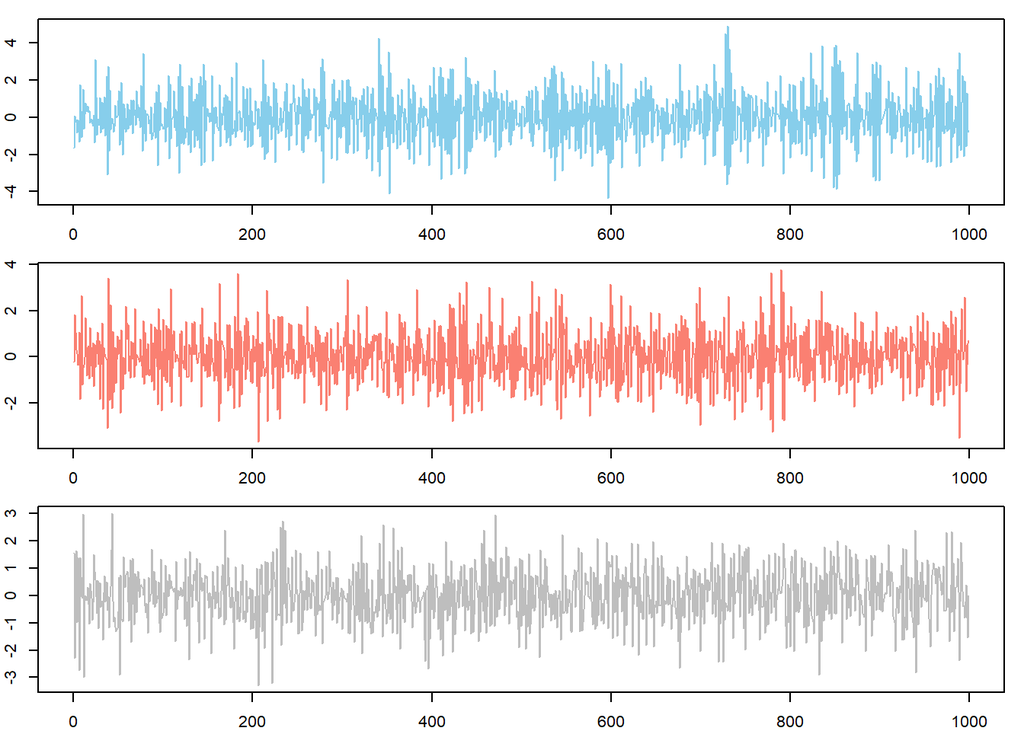

```r
par(mfcol = c(3,1), mar = c(2,2,1,1))
plot(as.numeric(AR_TRAIN[1,2:l+1]), ann=F,
     type="l", col="skyblue")
plot(as.numeric(AR_TRAIN[n+1,2:l+1]), ann=F,
     type="l", col="salmon")
plot(as.numeric(AR_TRAIN[2*n+1,2:l+1]), ann=F,
     type="l", col="grey")
```

# ARMA(1,1). Simulated autoregresive and moving average process.

Now, we are going to create 200 time-series per class. Each class will have a different combination of $\phi$ (AR(1) process) and $\theta$ (Ma(1) process) parameters.

```r
set.seed(456)
# parameters list for AR and MA process
parameters <- c(-.3, .5)

# create a empty matrix to load the time-series
classes <- length(parameters)^2 #
n <- 200  #number of time series per class
l <- 1000 #time series length
ARMA_TRAIN <- matrix(ncol = l+1, nrow = n*classes)
ARMA_TEST <- matrix(ncol = l+1, nrow = n*classes)

# create time series
cla <- 1
r <- 1
for (p in parameters) {
  for (q in parameters){
    for (i in 1:n) {
      ARMA_TRAIN[r,] <- c(cla,
                          arima.sim(model = list(ar = p, ma = q), n = l))
      ARMA_TEST[r,] <- c(cla,
                         arima.sim(model = list(ar = p, ma = q), n = l))
      r <- r + 1
    }
    cla <- cla + 1
  }
}
```

Let’s see a couple of examples.

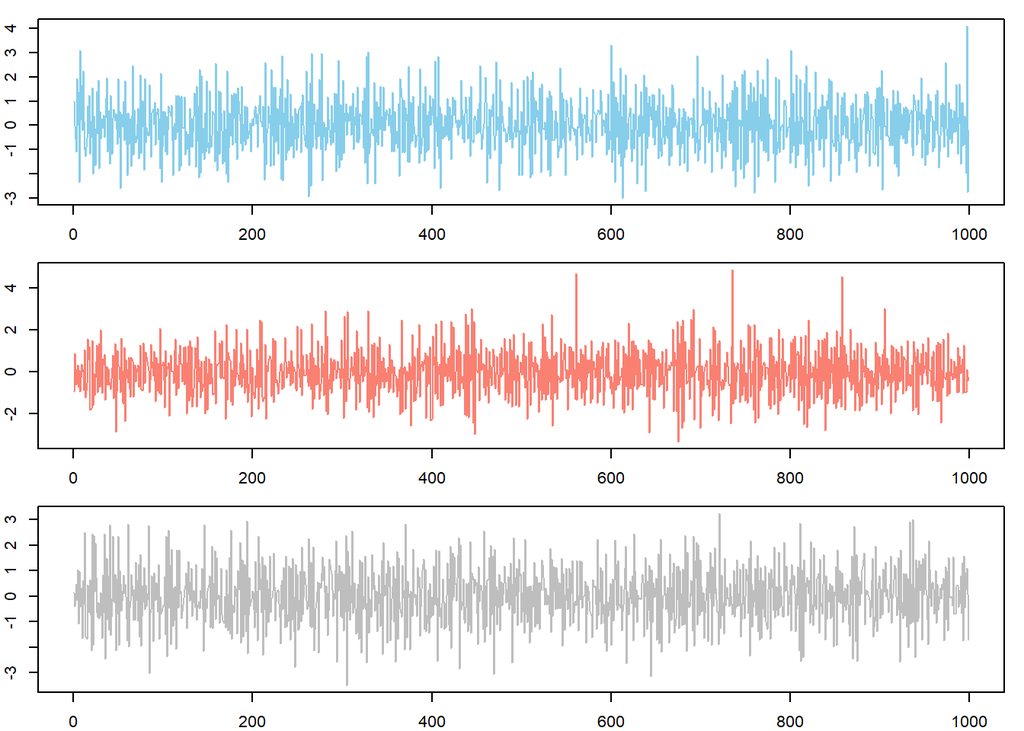

```r
par(mfcol = c(3,1), mar = c(2,2,1,1))
plot(as.numeric(ARMA_TRAIN[1,2:l+1]), ann=F,
     type="l", col="skyblue")
plot(as.numeric(ARMA_TRAIN[2,2:l+1]), ann=F,
     type="l", col="salmon")
plot(as.numeric(ARMA_TRAIN[3,2:l+1]), ann=F,
     type="l", col="grey")
```

# ARIMA(1,1,1)

Now, we are going to create 200 time-series per class. Each class will have a different combination of $\phi$ (AR(1) process) and $\theta$ (Ma(1) process) parameters. For all ARIMA(p,d,q) time-series, the parameter $d$ is equal to 1.

```r
set.seed(789)
# parameters list for AR and MA process
parameters <- c(-.3, .5)

# create a empty matrix to load the time-series
classes <- length(parameters)^2
n = 200  #number of time series per class
l = 1000 #time series legth
ARIMA_TRAIN <- matrix(ncol = l+1, nrow = n*classes)
ARIMA_TEST <- matrix(ncol = l+1, nrow = n*classes)

# create time series
cla <- 1
r <- 1
for (p in parameters) {
  for (q in parameters){
    for (i in 1:n) {
      ARIMA_TRAIN[r,] <- arima.sim(model = list(order = c(1,1,1),
                                                 ar = p, ma = q), n=l)
      ARIMA_TEST[r,] <- arima.sim(model = list(order = c(1,1,1),
                                                ar = p, ma = q), n=l)
      #the first value created is always zero, so we replace the zero with the class
      ARIMA_TRAIN[r,1] = cla
      ARIMA_TEST[r,1] = cla
      r <- r + 1
    }
    cla <- cla + 1
  }
}
```

Let’s see a couple of examples.

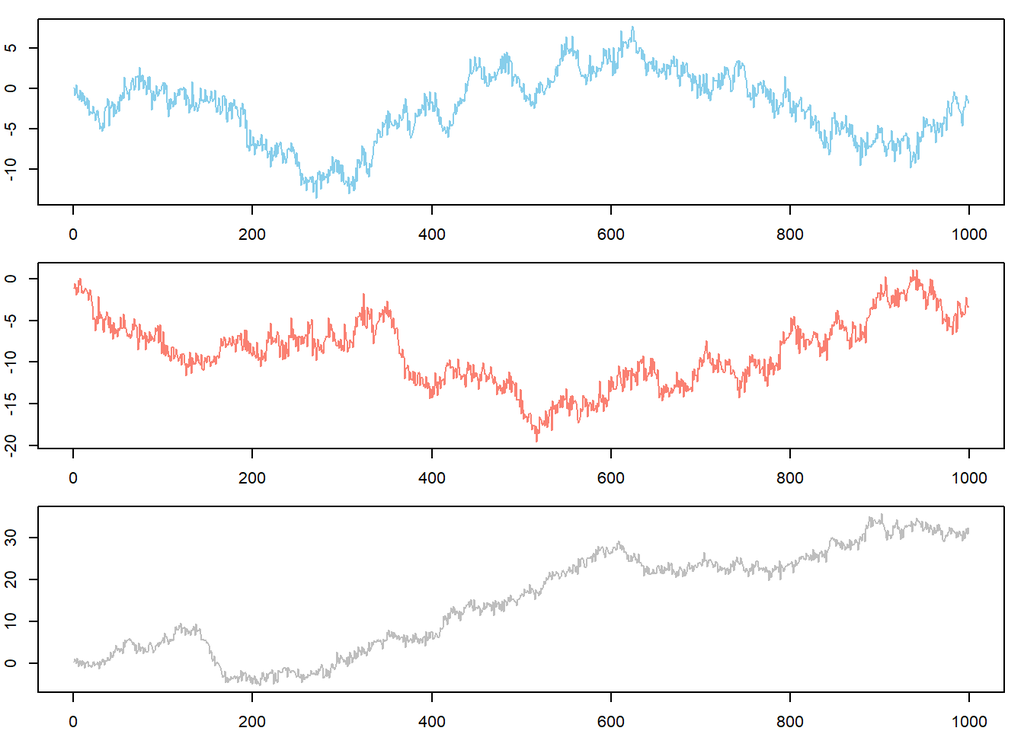

```r
par(mfcol = c(3,1), mar = c(2,2,1,1))
plot(as.numeric(ARIMA_TRAIN[1,2:l]), ylab = "", xlab = "",
     type="l", col="skyblue")
plot(as.numeric(ARIMA_TRAIN[2,2:l]), ylab = "", xlab = "",
     type="l", col="salmon")
plot(as.numeric(ARIMA_TRAIN[3,2:l]), ylab = "", xlab = "",
     type="l", col="grey")
```

We export as .csv files.

```r
write.csv(AR_TEST, "AR1_TEST.csv", row.names=FALSE)
write.csv(AR_TRAIN, "AR1_TRAIN.csv", row.names=FALSE)
```

```r
write.csv(ARMA_TEST, "ARMA11_TEST.csv", row.names=FALSE)
write.csv(ARMA_TRAIN, "ARMA11_TRAIN.csv", row.names=FALSE)
```

```r
write.csv(ARIMA_TEST, "ARIMA111_TEST.csv", row.names=FALSE)
write.csv(ARIMA_TRAIN, "ARIMA111_TRAIN.csv", row.names=FALSE)
```